# Taxa de Alfabetização nos Continentes

## Introdução

A taxa de alfabetização é um indicador crucial para entender o nível de educação de uma população e o acesso a oportunidades. Os gráficos a seguir apresentarão a evolução da taxa de alfabetização por continente entre os anos de 2000 e 2023, com um foco especial nas diferenças regionais. A análise busca entender as variações entre os continentes da Europa, América, África e Ásia, explorando os fatores históricos, econômicos e sociais que influenciam esses índices. A partir desses dados, podemos refletir sobre o impacto da alfabetização no desenvolvimento de uma sociedade, tanto no nível individual quanto coletivo.

## O que é alfabetização?

A alfabetização é um processo de aprendizado que capacita o indivíduo a ler, escrever de acordo com as regras e convenções de um idioma, interpretar textos, analisar informações e criar conteúdo. Para que um indivíduo seja considerada alfabetizado, não basta apenas entender palavras isoladas, ele deve ser capaz de se comunicar de forma funcional na sociedade, utilizando a leitura e a escrita para participar ativamente da vida social e tomar decisões informadas.

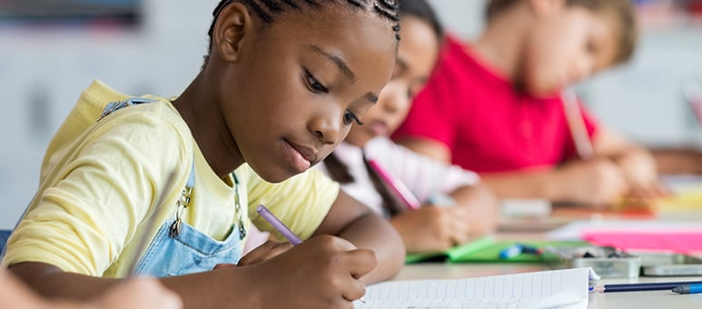

## Qual a sua importância?

um alto índice de alfabetização não apenas melhora a vida individual de cada cidadão, mas também traz benefícios econômicos, sociais, culturais e democráticos para toda a sociedade.

#### Benefícios para o indivíduo

- Acesso a educação
- Inserção no mercado de trabalho
- Autonomia
- Cidadania ativa

#### Benefícios para a sociedade

- Qualidade da educação
- Maior produtividade
- Redução de desigualdades
- Fortalecimento da cidadania
- Saúde pública

## Evolução da taxa de alfabetização dos continentes (2000-2023)

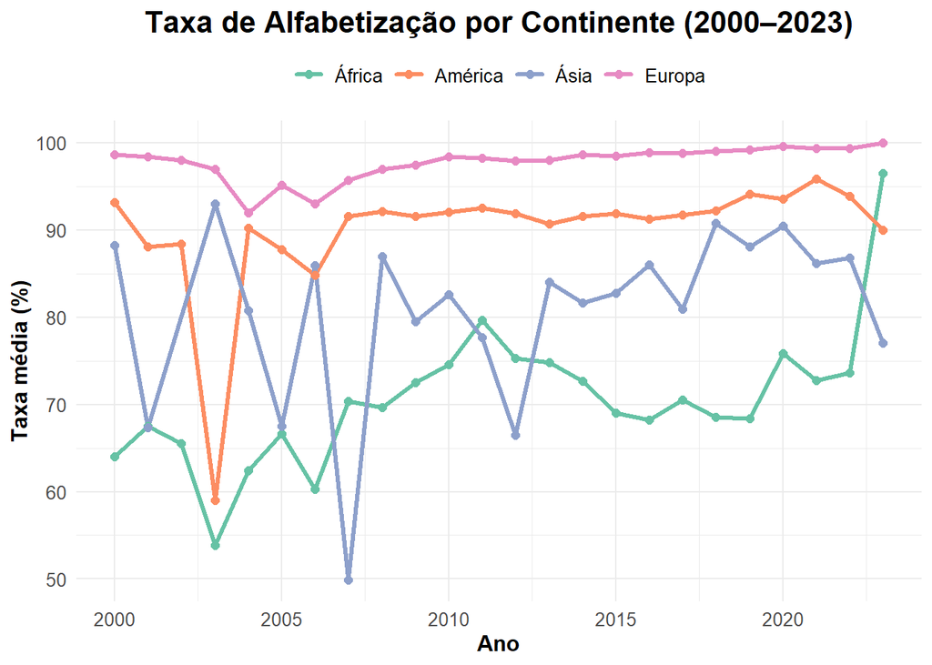

## Alfabetização dos continentes em 2020

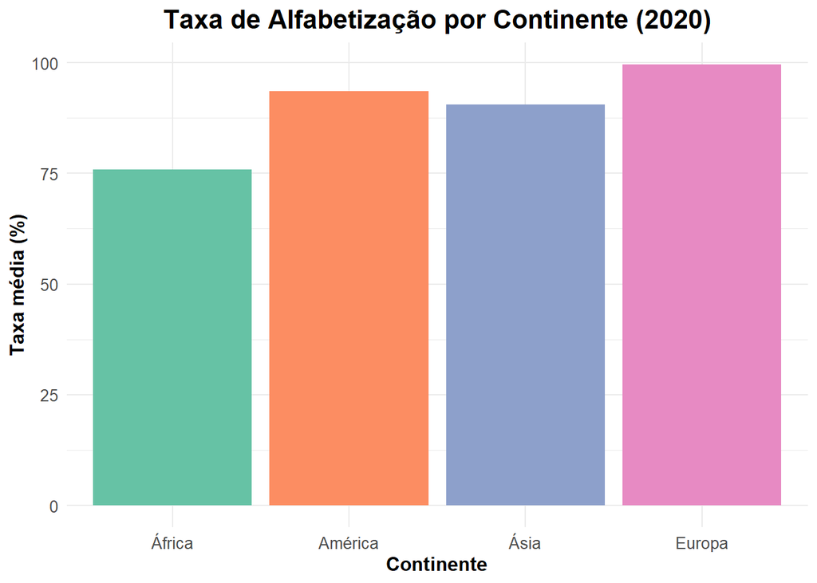

Em 2020, a Europa se destaca com a maior taxa média de alfabetização, resultado de investimentos contínuos em educação pública, políticas de inclusão e estabilidade econômica. Em seguida, aparece a America, Ásia e a África apresentando as menores taxas e que é prejudicada por fatores como pobreza, conflitos armados, infraestrutura precária e dificuldade de acesso à escola, especialmente em áreas rurais.

## Evolução da taxa de alfabetização da Europa

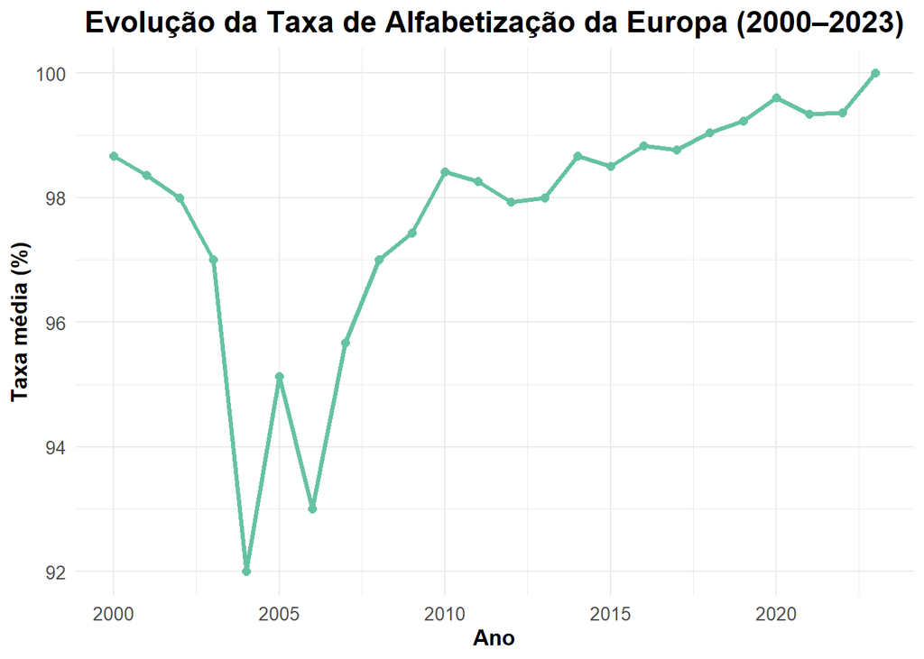

Países europeus implementaram sistemas de educação pública universal e gratuita, com ênfase na igualdade de oportunidades para todos os cidadãos desde o pós-Segunda Guerra Mundial. Durante a Revolução Industrial, o crescimento econômico impulsionou investimentos em educação, criando um sistema mais acessível. Além disso, a riqueza histórica da Europa também desempenhou um papel crucial no aumento das taxas de alfabetização. A estabilidade política e os avanços econômicos pós-guerras ajudaram a consolidar esse desenvolvimento, permitindo maior acesso à educação, o que contribuiu para a alta taxa de alfabetização no continente.

**Feito por Lígia Isaura Sartori.**